# Bootstrap

2020-11-18

## Bootstrap using R

## Sampling distribution

- If the population distribution is known, we can sample from it many times to get an idea of the sampling distribution.
- Example: \(X_i \sim N(\mu, \sigma^2), i = 1, \ldots, n\).
- Sampling distribution of \(\bar{X}\) is \(N(\mu, \sigma^2/n)\)
- Also, we can draw from normal many times, and plot the histogram of all the means.

## Sampling distribution Normal mean

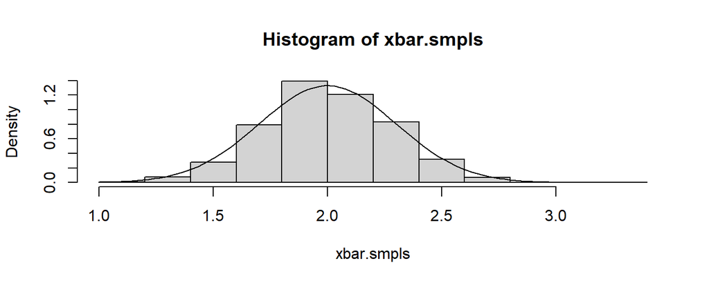

```r
set.seed(123)
x = rnorm(100,2,3)
xbar.smpls = rep(NA, 1000)
for (i in 1:1000)  xbar.smpls[i] = mean(rnorm(100,2,3))
hist(xbar.smpls, freq = FALSE)
curve(dnorm(x,mean=2,sd=3/10),add=T)
```

## Use of sampling distribution

- We can use the sampling distribution to get an idea about the fluctuation of the sample mean etc.
- The true sampling mean should be 2, and true sampling std. dev. should be \(\sigma/\sqrt{n}= 3/\sqrt(100) = 0.3\).

```r
mean(xbar.smpls)
```

```
## [1] 2.00255
```

```r
sd(xbar.smpls)
```

```
## [1] 0.2851543
```

## Bootstrap

1. If \(F\) is completely unknown, we cannot generate random numbers from this distribution.
2. \(X_1, \ldots, X_n\) are the only realizations of \(F\) known to us. The idea is to approximate \(F\) by \(\hat F\) based on \(X_1, \ldots, X_n\).
3. Basic idea: Inference about a population from sample data, (sample \(\rightarrow\) population), can be modeled by resampling the sample data and performing inference about a sample from resampled data, (resampled \(\rightarrow\) sample).

## Algorithm

1. Data: \(X_1, \ldots, X_n\). Test statistics \(t_n\) (e.g. \(\bar{X}\))
2. Draw \(B\) samples \(x_1^b, x_2^b, \ldots, x_n^b\) with replacement \(b = 1, \ldots, B\) (there might be ties). This is called a **Bootstrap sample**!
3. For each of the \(B\) samples calculate the statistic \(t_n^b\).
4. Use these \(B\) realizations of \(t_n\) to compute whatever you want, e.g.
- mean: \(E(t_n) \approx 1/B \sum_b t_n^b\).
- variance: \(Var(t_n) \approx 1/(B-1) \sum_b (t_n^b - \bar{t}_n)^2\).
- Empirical CDF \(\hat{F}(t_n)\).

## Bootstrap in R - the sample() function

A major component of bootstrapping is being able to resample a given data set and in R the function which does this is the sample function.

sample(x, size, replace, prob)

- The first argument is a vector containing the data set to be resampled or the indices of the data to be resampled.
- The size option specifies the sample size with the default being the size of the population being resampled.
- The replace option determines if the sample will be drawn with or without replacement where the default value is FALSE, i.e. without replacement.
- The prob option takes a vector of length equal to the data set given in the first argument containing the probability of selection for each element of x.

## More on sampling - 1

- Using sample to generate a permutation of the sequence 1:10

```r
sample(10)
```

```
##  [1]  4  1  5 10  3  9  8  6  7  2
```

- Bootstrap sample from the same sequence (ties)

```r
sample(10, replace=T)
```

```
##  [1]  1  9  5  8  1 10  7  5  5  6
```

```r
sample(10, replace=T)
```

```
##  [1]  5 10 10  1  7  5  6  8  8 10
```

## More on sampling - 2

- Boostrap sample from the same sequence with probabilities that favor the numbers 1-5

```r
prob1 <- c(rep(.15, 5), rep(.05, 5))
prob1
```

```
##  [1] 0.15 0.15 0.15 0.15 0.15 0.05 0.05 0.05 0.05 0.05
```

```r
sample(10, replace=T, prob=prob1)
```

```
##  [1] 4 8 4 3 7 5 5 3 1 7
```

## Bootstrap in R

- Here is an R code for getting the bootstrap samples from the same \(x\) that we saw before.

```r
B = 5000
theta.boot = rep(0, B)
n = length(x)
for (b in 1:B)  theta.boot[b] = mean(sample(x,replace=TRUE))
```

## Bootstrap mean and sd

- We can use the statistics calculated from the bootstrap distribution to get an idea about the fluctuation of the sample mean etc. when the true F is not known.

```r
mean(theta.boot)
```

```
## [1] 2.271241
```

```r
sd(theta.boot)
```

```
## [1] 0.2682298
```

## The bootstrap distribution

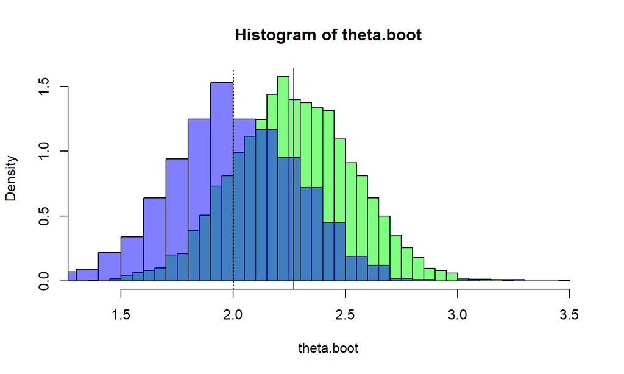

## Another Example - 0

- Taken entirely from [ATS UCLA website](http://www.ats.ucla.edu/stat/r/library/bootstrap.htm)
- In the following bootstrapping example we would like to obtain a standard error for the estimate of the median.
- We will use the lapply and sapply functions.
- lapply(X, FUN, …): returns a list of the same length as X, each element of which is the result of applying FUN to the corresponding element of X.
- sapply(X, FUN, …) is a user-friendly version and wrapper of lapply by default returning a vector, matrix or, if simplify = “array”, an array if appropriate.

## Another Example - 1

- We want to calculating the standard error of the median for a data set created by taking 100 observations from a normal distribution with mean 5 and stdev 3.
- We have rounded each observation to nearest integer!
- The distribution of median is not as `simple’ as the mean.

```r
data <- round(rnorm(100, 5, 3))
data[1:10]
```

```
##  [1]  6  4  9  4  1  4  2 11  9  8
```

## Another Example - 2

- We will generate only 20 bootstrap samples.
- Show the first sample for demonstration.

```r
resamples <- lapply(1:20, function(i)
sample(data, replace = T))
resamples[1]
```

```
## [[1]]
##   [1]  4  4  8  4  1 -2  5  5  4  7  4  6  6 11  1  5  6  5  9  4 10 -1  4  4  4
##  [26] 10  5  7  3  4  4  7  6  3  9  5  6  0  4  4  6  3  1 11  7  4  9  7  7 11
##  [51]  9 12  4  4  3  7  2  4  7  4  5  8  4  0  7  6  4  6  9  6  6  7  5  6 12
##  [76]  4  4  5  7 10  1  7  7 10  4  3  1  5  4  4  0  8  1  8  4  2  5  6 11 11
```

## Another Example - 3

- For each bootstrap samples, we will calculate the median.
- Now we have a bootstrap sample from the distribution of the sample median, and we can use it to calculate the standard deviation.

```r
r.median <- sapply(resamples, median)
r.median
```

```
##  [1] 5.0 5.0 5.0 6.0 5.0 5.0 5.0 5.0 5.0 5.0 5.0 4.5 5.0 5.0 5.0 6.0 5.0 5.0 5.0
## [20] 6.0
```

```r
sqrt(var(r.median))
```

```
## [1] 0.3931988
```

## Another Example - 4

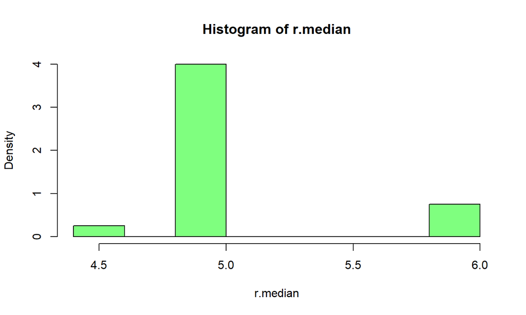

```r
hist(r.median, freq = FALSE, col = rgb(0,1,0,0.5))
```

## Using package

```r
# Bootstrap 95% CI for R-Squared
library(boot)
# function to obtain R-Squared from the data
rsq <- function(formula, data, indices) {
  d <- data[indices,] # allows boot to select sample
  fit <- lm(formula, data=d)
  return(summary(fit)$r.square)
}
# bootstrapping with 1000 replications
results <- boot(data=mtcars, statistic=rsq,
    R=1000, formula=mpg~wt+disp)
```

## Using package

```r
# view results
results
```

```
##
## ORDINARY NONPARAMETRIC BOOTSTRAP
##
##
## Call:
## boot(data = mtcars, statistic = rsq, R = 1000, formula = mpg ~
##     wt + disp)
##
##
## Bootstrap Statistics :
##      original     bias    std. error
## t1* 0.7809306 0.01138209  0.04917415
```

## Using package

You can also get them separately:

```r
(bs.median = results$t0)
```

```
## [1] 0.7809306
```

```r
(bs.stderr = sqrt(var(results$t)))
```

```
##            [,1]
## [1,] 0.04917415
```

## Plotting results

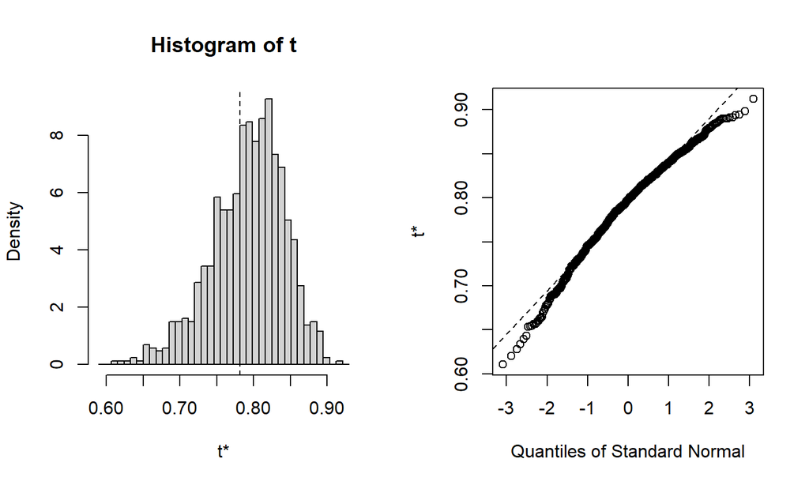

```r
plot(results)
```

## Plotting results

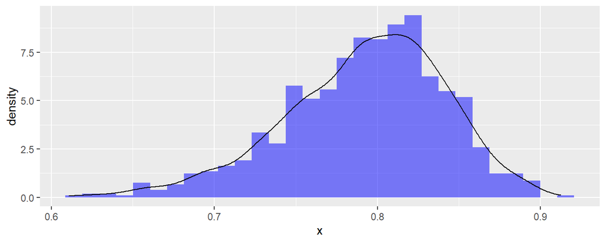

```r
df <- data.frame(x = results$t); x<- df$x
library(ggplot2)
ggplot(df, aes(x)) + geom_histogram(aes(y = ..density..), fill = "blue", alpha = 0.5)+geom_density()
```

## Law data example

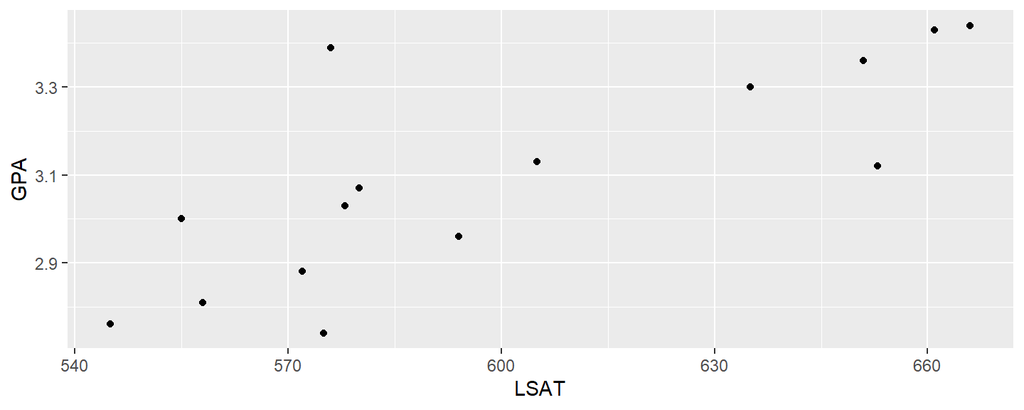

```r
data(law, package = "bootstrap")
library(ggplot2)
qplot(LSAT, GPA, data = law)
```

```r
with(law, cor(LSAT, GPA))
```

```
## [1] 0.7763745
```

## Sample with replacement

```r
sample(nrow(law), replace = TRUE)
```

```
##  [1]  3  1 10  1 14  2 13 14  3  5  3  3  1  8  5
```

```r
sample(nrow(law), replace = TRUE)
```

```
##  [1]  7  6  3 12  8 12  5  7  9  2  3  4  4  4  3
```

```r
with(law[sample(nrow(law), replace = TRUE), ], cor(LSAT, GPA))
```

```
## [1] 0.6162869
```

```r
with(law[sample(nrow(law), replace = TRUE), ], cor(LSAT, GPA))
```

```
## [1] 0.7647155
```

```r
with(law[sample(nrow(law), replace = TRUE), ], cor(LSAT, GPA))
```

```
## [1] 0.8670833
```

## Bootstrap (Long code)

```r
ptm <- proc.time()
B <- 5000
cor.boot <- rep(0,B)
for (b in 1:B){
  law.boot <- law[sample(nrow(law), replace = TRUE), ]
  cor.boot[b] = cor(law.boot$LSAT, law.boot$GPA)
}
summary(cor.boot)
```

```
##    Min. 1st Qu.  Median    Mean 3rd Qu.    Max.
## 0.00217 0.69120 0.78835 0.76975 0.87130 0.99465
```

```r
proc.time()-ptm
```

```
##    user  system elapsed
##    0.73    0.00    0.73
```

## Bootstrap (Short code)

```r
ptm <- proc.time()
B <- 5000
cors <- replicate(B, {with(law[sample(nrow(law), replace = TRUE), ],
                           cor(LSAT, GPA))})
summary(cors)
```

```
##    Min. 1st Qu.  Median    Mean 3rd Qu.    Max.
##  0.1565  0.6890  0.7890  0.7707  0.8721  0.9917
```

```r
proc.time()-ptm
```

```
##    user  system elapsed
##    0.69    0.00    0.69
```

- Slight gain in running time! Gets better with bigger data.

## Plotting results

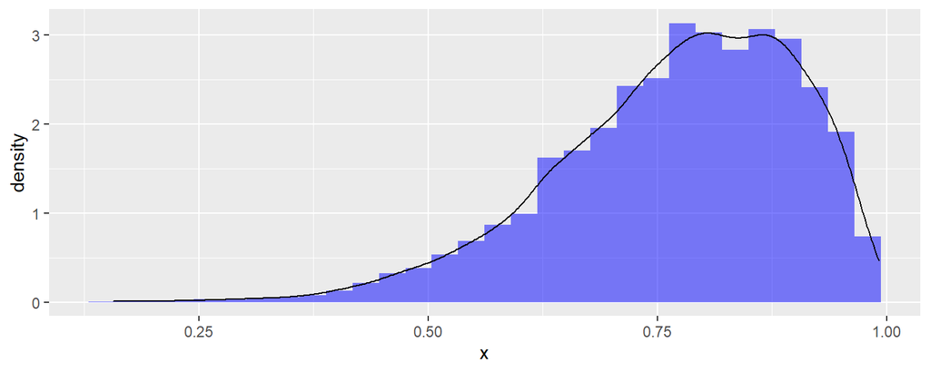

```r
df <- data.frame(x = cors); x<- df$x
library(ggplot2)
ggplot(df, aes(x)) + geom_histogram(aes(y = ..density..), fill = "blue", alpha = 0.5)+geom_density()
```

## How many bootstrap samples do we need?

- We will perform Bootstrap sampling for different values of \(B\), the number of Bootstrap samples and observe the fluctuation between bootstrap estimates for each choice.
- Our preferred \(B\) should lead to a low variation.
- We will show the standard loop-y code, which is not efficient and a fast code.

## Design

```r
Bs <- rep(100 * (1:50), 3)
Bs
```

```
##   [1]  100  200  300  400  500  600  700  800  900 1000 1100 1200 1300 1400
##  [15] 1500 1600 1700 1800 1900 2000 2100 2200 2300 2400 2500 2600 2700 2800
##  [29] 2900 3000 3100 3200 3300 3400 3500 3600 3700 3800 3900 4000 4100 4200
##  [43] 4300 4400 4500 4600 4700 4800 4900 5000  100  200  300  400  500  600
##  [57]  700  800  900 1000 1100 1200 1300 1400 1500 1600 1700 1800 1900 2000
##  [71] 2100 2200 2300 2400 2500 2600 2700 2800 2900 3000 3100 3200 3300 3400
##  [85] 3500 3600 3700 3800 3900 4000 4100 4200 4300 4400 4500 4600 4700 4800
##  [99] 4900 5000  100  200  300  400  500  600  700  800  900 1000 1100 1200
## [113] 1300 1400 1500 1600 1700 1800 1900 2000 2100 2200 2300 2400 2500 2600
## [127] 2700 2800 2900 3000 3100 3200 3300 3400 3500 3600 3700 3800 3900 4000
## [141] 4100 4200 4300 4400 4500 4600 4700 4800 4900 5000
```

## How many? (slow code)

```r
ptm <- proc.time()
corsize2 = matrix(0,length(Bs),2)
for (i in 1:length(Bs)){
  b = Bs[i]
  for (b in 1:B){
   law.boot <- law[sample(nrow(law), replace = TRUE), ]
   cor.boot[b] = cor(law.boot$LSAT, law.boot$GPA)
  }
  corsize2[i,] = c(b, mean(cor.boot))
}
colnames(corsize2) = c("B","cor")
proc.time()-ptm
```

```
##    user  system elapsed
##  109.58    0.33  121.28
```

```r
head(corsize2, n = 3)
```

```
##         B       cor
## [1,] 5000 0.7674854
## [2,] 5000 0.7736561
## [3,] 5000 0.7734934
```

## Fast code for Bootstrap sample size

- The idea is to calculate the bootstrap correlation for each sample size from 100 to 5000, and replicate three times.
- The slow code uses a nested for loop, which is really inefficient.
- We can use a function called `ldply` that can avoid for loops altogether.
- ldply function : For each element of a list, apply function then combine results into a data frame.
- Our list is values of B, for each B, we will calculate mean of correlation estimates for a bootstrap with B samples.

## How many? (Fast Code)

```r
ptm <- proc.time()
library(plyr)
corsize <- ldply(Bs, function(B){
                 cors <- replicate(B,{with(law[sample(nrow(law), replace = TRUE),]                                      ,cor(LSAT, GPA))})
                 c(B = B, cor = mean(cors))})
head(corsize,n=3)
```

```
##     B       cor
## 1 100 0.7676786
## 2 200 0.7787451
## 3 300 0.7638906
```

```r
proc.time()-ptm
```

```
##    user  system elapsed
##   52.80    0.08   54.36
```

## Plot

- Plot the correlation estimates for each value of \(B\) for three choices.
- As \(B\) increases, fluctuation diminishes.

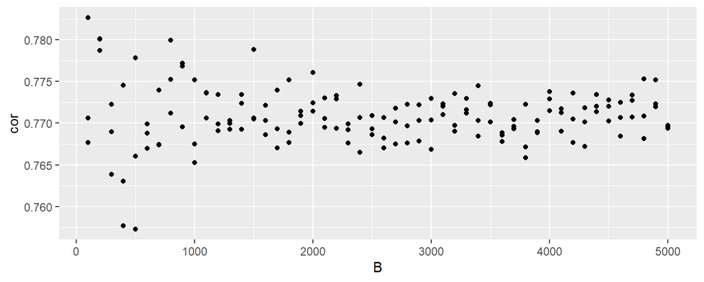

```r
qplot(B, cor, data = corsize)
```